# R Notebook

The following code is used to test hypothesis related to the relationship between a country’s forest area, level of CO2 emissions and the employment rate.

We will be calling an excel file from Github and reading it into R. For R to read the excel file we call-up the ‘rio’ package from the R Library. After reading in the data frame, we name it TM2_Data.

```r
library(rio)
#install_formats()
linkexcel='https://github.com/PUBPOL542G3/G3_Merge/blob/main/Triple_Merge.xlsx?raw=true'
TM2_Data=import(linkexcel)
```

This code resets the indexes of TM2_Data to match the “R” format indexes.

```r
row.names(TM2_Data)=NULL
```

```r
str(TM2_Data,width = 50,strict.width='cut')
```

```
## 'data.frame':    179 obs. of  4 variables:
##  $ country    : chr  "Afghanistan" "Albania" "A"..
##  $ employment : num  0.491 0.468 0.368 0.721 0.5..
##  $ CO2        : num  0.262 1.6 3.8 1.22 4.64 1.6..
##  $ forest_area: num  1208 789 1956 69383 29097 ...
```

Here we state our hypotheses as the following: Hypothesis 1: we expect forest area to increase as CO2 decreases Hypothesis 2: we expect forest area to increase as employment & CO2 decrease The second hypothesis examines the interaction between employment and CO2. The regression for the second hypothesis takes on the form: forest area = constant + a_CO2 + b_employment + c_CO2*employment

```r
hypo1=formula(forest_area~ CO2)
hypo2=formula(forest_area~ employment*CO2)
```

The code below computes the two gaussian regression models for the hypotheses listed above.

```r
gauss1=glm(hypo1,
           data = TM2_Data,
           family = 'gaussian')

gauss2=glm(hypo2,
           data = TM2_Data,
           family = 'gaussian')
```

```r
summary(gauss1)
```

```
##
## Call:
## glm(formula = hypo1, family = "gaussian", data = TM2_Data)
##
## Deviance Residuals:
##    Min      1Q  Median      3Q     Max
## -87730  -20344  -15016   -6883  780320
##
## Coefficients:
##             Estimate Std. Error t value Pr(>|t|)
## (Intercept)    14845       7575   1.960   0.0516 .
## CO2             1765       1017   1.735   0.0845 .
## ---
## Signif. codes:  0 '***' 0.001 '**' 0.01 '*' 0.05 '.' 0.1 ' ' 1
##
## (Dispersion parameter for gaussian family taken to be 6551986200)
##
##     Null deviance: 1.1794e+12  on 178  degrees of freedom
## Residual deviance: 1.1597e+12  on 177  degrees of freedom
## AIC: 4557.9
##
## Number of Fisher Scoring iterations: 2
```

```r
summary(gauss2)
```

```
##
## Call:
## glm(formula = hypo2, family = "gaussian", data = TM2_Data)
##
## Deviance Residuals:
##     Min       1Q   Median       3Q      Max
## -101347   -22681   -13010    -2260   772377
##
## Coefficients:
##                Estimate Std. Error t value Pr(>|t|)
## (Intercept)      -43741      36574  -1.196   0.2333
## employment        93309      59646   1.564   0.1195
## CO2               10343       5436   1.903   0.0587 .
## employment:CO2   -12721       7835  -1.624   0.1063
## ---
## Signif. codes:  0 '***' 0.001 '**' 0.01 '*' 0.05 '.' 0.1 ' ' 1
##
## (Dispersion parameter for gaussian family taken to be 6500612317)
##
##     Null deviance: 1.1794e+12  on 178  degrees of freedom
## Residual deviance: 1.1376e+12  on 175  degrees of freedom
## AIC: 4558.5
##
## Number of Fisher Scoring iterations: 2
```

This code uses the anova function to search for the better of our two regression models (i.e. hypothesis 1 and hypothesis 2). After running the function, neither model seemed very promising.

```r
anova(gauss1,gauss2,test="Chisq")
```

|  | Resid. Df | Resid. Dev | Df | Deviance | Pr(>Chi) |
| --- | --- | --- | --- | --- | --- |
| 1 | 177 | 1.159702e+12 | NA | NA | NA |
| 2 | 175 | 1.137607e+12 | 2 | 22094402039 | 0.1827915 |

This code calls up the RSquared packages from the R library. We use this function to view the R squared value of our second gaussian model. The function revealed a very low RSquared value which means that out model only explains ~2% of the variance in our data.

```r
library(rsq)
rsq(gauss2,adj=T)
```

```
## [1] 0.01892164
```

We can also create a dotwhisker plot in order to see the variance in our data. To do this we call on the dotwhisker package from the library.

```r
#install.packages("dotwhisker")
library(dotwhisker)
```

The dwplot command displays our three variables in dotwhisker plot form. These plots show that our employment data has very long ‘whiskers’ representing a wide range of data points.

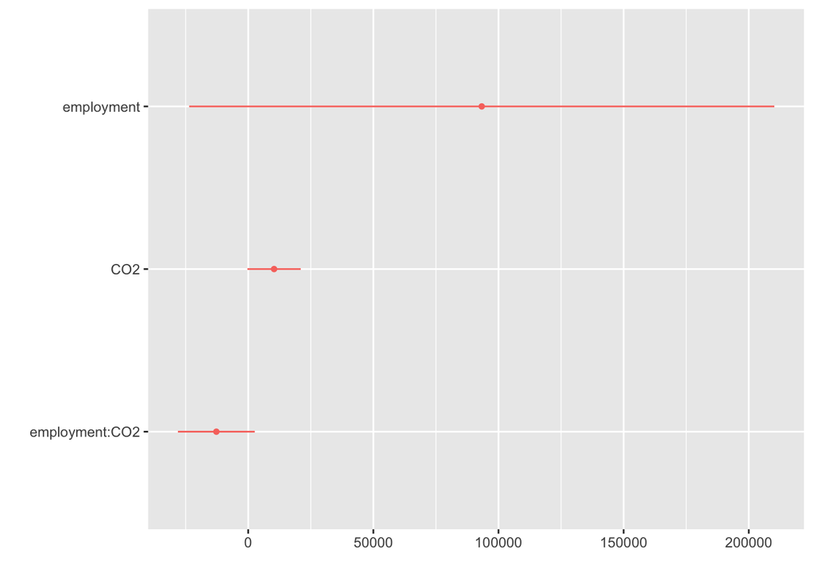

```r
dwplot(gauss2,by_2sd = F)
```

This code calls up the margins package from the R library. With margins we create another data visualization that depicts the marginal effects of the CO2 variable in the model.

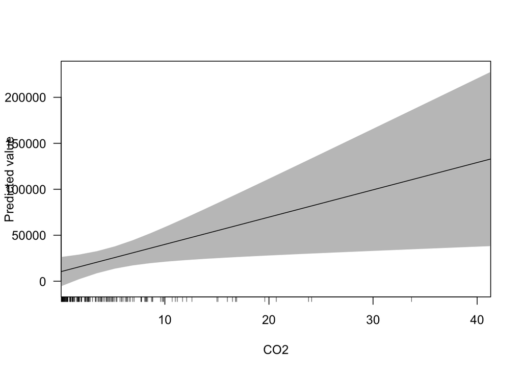

```r
library(margins)
cplot(gauss2,'CO2')
```

We repeat the same command as above, however, this time we are using the employment variable in the model.

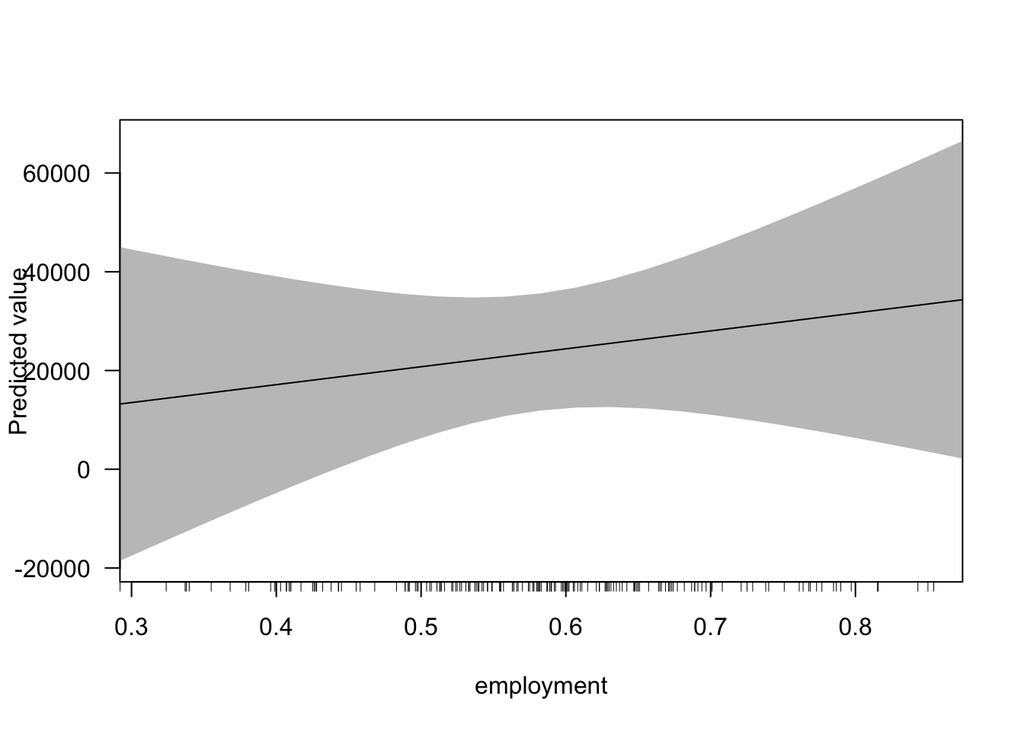

```r
cplot(gauss2,'employment')
```

Using the persp function, we are also able to plot the interaction effect between CO2 and employment.

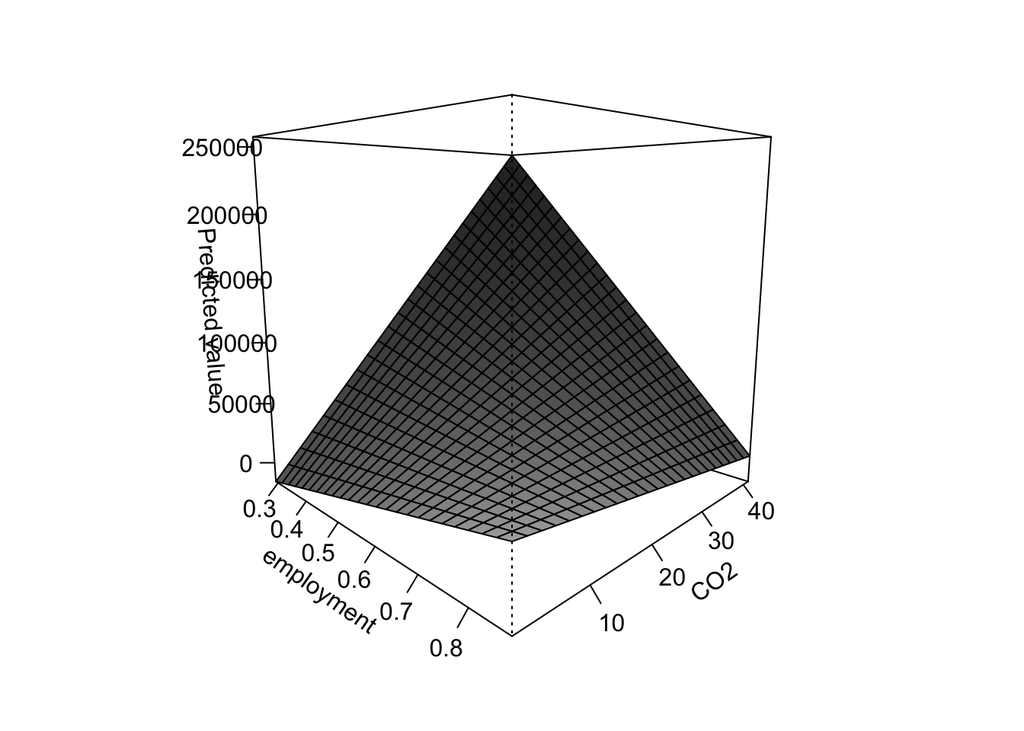

```r
persp(gauss2)
```